# Day 5 KNN classification

```r
library(tidyverse)
setwd("/Users/pp16/Desktop/NTU/UCL exchange/week 1 day 5")
```

```r
dragonfly <- read_csv("dragonfly.csv")
```

```r
dragonfly <- mutate(dragonfly, species=factor(species))
```

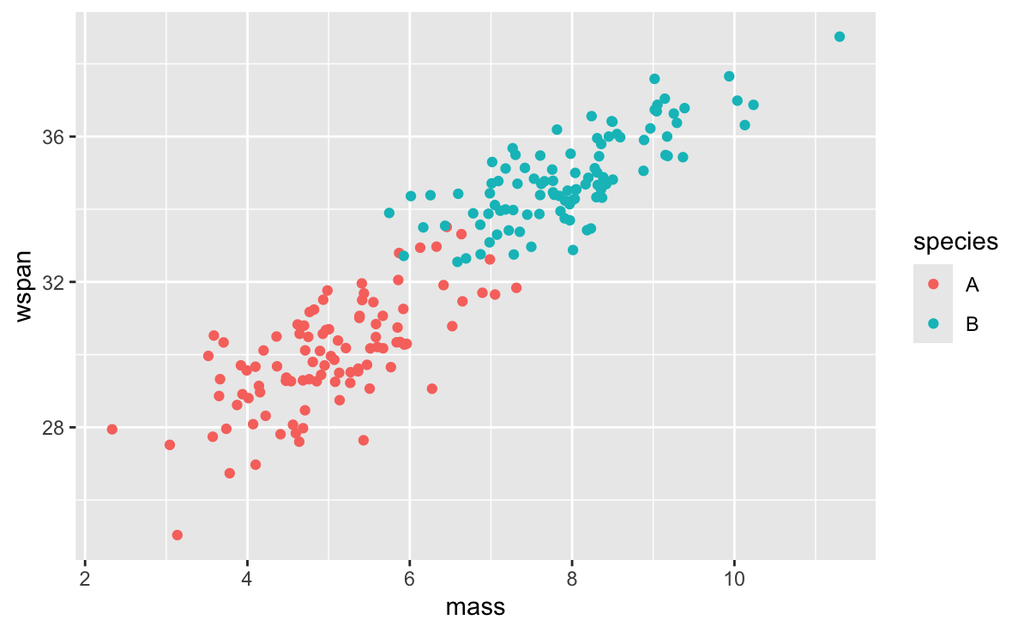

```r
ggplot(data = dragonfly,
       mapping=aes(y=wspan,
                   x=mass,
                   color=species)) +
  geom_point()
```

We can see that:

there is a general trend, with larger mass meaning larger wingspan species A tends to have smaller wingspan and mass species B tends to have larger wingspan and mass the larger species A dragonflies are similar in size to smaller species B dragonflies.

```r
dragonfly2 <- read_csv("dragonfly2.csv")
```

```r
ggplot() +
  geom_point(data = dragonfly,
             mapping=aes(y=wspan,
                         x=mass,
                         color=species)) +
  geom_point(data = dragonfly2,
             mapping=aes(y=wspan,
                         x=mass),
             colour="black", size=0.5) +
  geom_text(data = dragonfly2,              # adds text labels from id column
            mapping=aes(y=wspan,
                        x=mass,
                        label=id),
            size=1.5,                       # adjusts text size
            nudge_y=.2)                     # nudges text up to avoid overlapping
```

Some points like (6/28) seems unclear to be species A or B hence we looking at the number of neighbours that belong to which species to identify that species.

```r
# create species column in dragonfly2 with NA entries
dragonfly2$species <- NA #add a column species to dragonfly2

dragonfly_all <- bind_rows(dragonfly, dragonfly2) #combine to a single dataframe
```

```r
# to mutate a set of columns we can use the mutate_at() function
# and pass the column names we want it to operate on

dragonfly_all_norm <- dragonfly_all %>%
  mutate_at(c("mass","wspan"),scale)

# after applying the same scaling to all the data we can split it back
# into the original groups

dragonfly_norm <- dragonfly_all_norm %>%  #if not na put in dragonfly_norm
  filter(is.na(species) == FALSE)

dragonfly2_norm <- dragonfly_all_norm %>% #if na put in dragonfly2_norm
  filter(is.na(species) == TRUE)
```

```r
df_train <- dragonfly_norm
df_test <- dragonfly2_norm
X_train <- select(df_train, wspan, mass)
Y_train <- df_train$species

# Note here we can't use Y_train <- select(df_train, species)
# because the select() function returns a data.frame with one column
# and knn() expects a vector not a dataframe

X_test <- select(df_test, wspan, mass)
```

Now we can apply the method using k=5 so that we look at the nearest 5 neighbours:

```r
install.packages(class)
library(class)

Y_test_predicted <- knn(X_train, X_test, Y_train, k=5)
```

Let’s put the prediction back into our dragonfly dataframe:

```r
df_test$species_predicted <- Y_test_predicted
```

```r
ggplot() +
  geom_point(data = df_train,
             mapping=aes(y=wspan,
                         x=mass,
                         color=species),
             alpha=0.1) +                 # alpha sets these to be transparent
  geom_point(data = df_test,
             mapping=aes(y=wspan,
                         x=mass,
                         color=species_predicted),
             shape=3, size=0.5) +
  geom_text(data = df_test,
            mapping=aes(y=wspan,
                        x=mass,
                        label=id),
            size=1.5,
            nudge_y=.2)
```

```r
df_test_labels <- read_csv("dragonfly2_labels.csv")
df_test$species_actual <- factor(df_test_labels$species_actual)

head(df_test)
```

```r
table(actual = df_test$species_actual,
      predicted = df_test$species_predicted)
```

```r
n_correct <- sum(df_test$species_actual == df_test$species_predicted)
n_incorrect <- sum(df_test$species_actual != df_test$species_predicted)

# how these work:
# df_test$species_actual == df_test$species_predicted
# produces vector of TRUE / FALSE values which
# stores TRUE where prediction matched values / FALSE otherwise
# sum() function acts to count number of TRUE entries in a vector
# as treats TRUE as having value 1 and FALSE having value 0

n_total <- n_correct + n_incorrect

accuracy <- n_correct / n_total
accuracy
```

# Exercise

- load file penguins_knn.csv this has an extra column species_actual containing all species which we can use to check the results.

```r
library(tidyverse)
penguin = read_csv("penguins_knn.csv")
```

- normalise the columns used for prediction species (flipper length, body mass, bill length, bill depth)

```r
penguin_all_norm = penguin %>%
  mutate_at(c("flipper_length_mm", "body_mass_g", "bill_length_mm", "bill_depth_mm"), scale)

penguin_norm = penguin_all_norm %>%
  filter(is.na(species) == FALSE) %>%
  filter(is.na(body_mass_g)==F) %>%
  filter(is.na(flipper_length_mm)==F)

penguin2_norm = penguin_all_norm %>%
  filter(is.na(species)==TRUE)
```

- construct dataframes penguin_train and penguin_test use ggplot to make a

```r
penguin_train = penguin_norm
penguin_test = penguin2_norm
```

- plot showing a geom_point scatter plot for the training data, colouring the points by species.

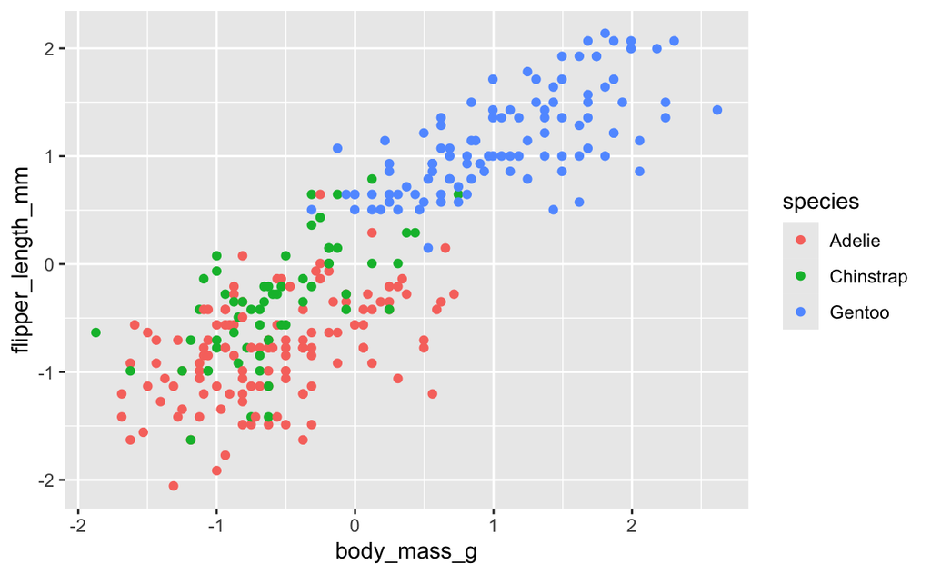

```r
ggplot() +
  geom_point(data = penguin_train,
             mapping = aes(y= flipper_length_mm, x= body_mass_g, color=species))
```

- modify the plot to include the points from the test dataset.

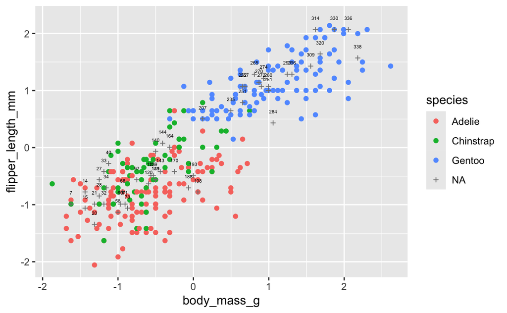

```r
ggplot() +
  geom_point(data = penguin_train,
             mapping = aes(y= flipper_length_mm, x= body_mass_g, color=species)) +
  geom_point(data=penguin_test,
             mapping=aes(y=flipper_length_mm, x=body_mass_g, color=species),
             shape=3, size=1) +
   geom_text(data = penguin_test,
            mapping=aes(y=flipper_length_mm,
                        x=body_mass_g,
                        label=id),
            size=1.5,
            nudge_y=.2)
```

- by referring to the example code above, construct X_train, Y_train, and X_test use the knn() function to create predictions setting to 5 and store the output as Y_test

```r
X_train = select(penguin_train, body_mass_g, flipper_length_mm)
Y_train = penguin_train$species
X_test = select(penguin_test, body_mass_g, flipper_length_mm)
#install.packages(class)
library(class)
set.seed(100)
Y_test <- knn(X_train, X_test, Y_train, k=5)
Y_test
```

```
 [1] Adelie    Adelie    Adelie    Adelie    Adelie    Adelie
 [7] Adelie    Chinstrap Adelie    Adelie    Chinstrap Adelie
[13] Chinstrap Adelie    Adelie    Adelie    Chinstrap Adelie
[19] Chinstrap Chinstrap Chinstrap Chinstrap Chinstrap Chinstrap
[25] Chinstrap Adelie    Adelie    Adelie    Adelie    Adelie
[31] Gentoo    Gentoo    Gentoo    Gentoo    Gentoo    Gentoo
[37] Gentoo    Gentoo    Gentoo    Gentoo    Gentoo    Gentoo
[43] Gentoo    Gentoo    Gentoo    Gentoo    Gentoo    Gentoo
[49] Gentoo    Gentoo
Levels: Adelie Chinstrap Gentoo
```

- write the predictions Y_test into the penguin test dataframe as species_predicted
- create a confusion table to display the results.

```r
penguin_test$species_predicted = Y_test
table(actual = penguin_test$species_actual, predicted = penguin_test$species_predicted)
```

```
           predicted
actual      Adelie Chinstrap Gentoo
  Adelie        18         2      0
  Chinstrap      1         9      0
  Gentoo         0         0     20
```

Check you can interpret it by answering the following questions: - How many penguins in the test dataset were predicted as Adelie? 18+1 = 19 - How many penguins in the test dataset were actually Adelie? 18+2 = 20 - How many penguins in the test dataset were correctly predicted Gentoo? 20 - How many penguins in the test dataset were incorrectly predicted Gentoo? 0 - How many penguins in the test dataset were actually Chinstrap but predicted to be Adelie? 1

- calculate the number of correct predictions,and the overall accuracy.

```r
n_correct = sum(penguin_test$species_actual == penguin_test$species_predicted)
n_incorrect = sum(penguin_test$species_actual != penguin_test$species_predicted)
n_total = n_correct + n_incorrect
accuracy = n_correct/n_total
accuracy
```

```
[1] 0.94
```

```r
(18+9+20) / 50
```

```
[1] 0.94
```